# troubleshooting with training and choice lables

morgan moyer

2024-10-23

# Take a look at trianing items

In these trails, F and J keys aren’t switching like they should.

```r
length(unique(d.train$ID.true))
```

```
## [1] 40
```

```r
table(d.train$Task, d.train$Key_value_F)
```

```
##
##            abstract negative
##   Concrete      410        0
##   Valence         0      410
```

```r
# Create proportion column
```

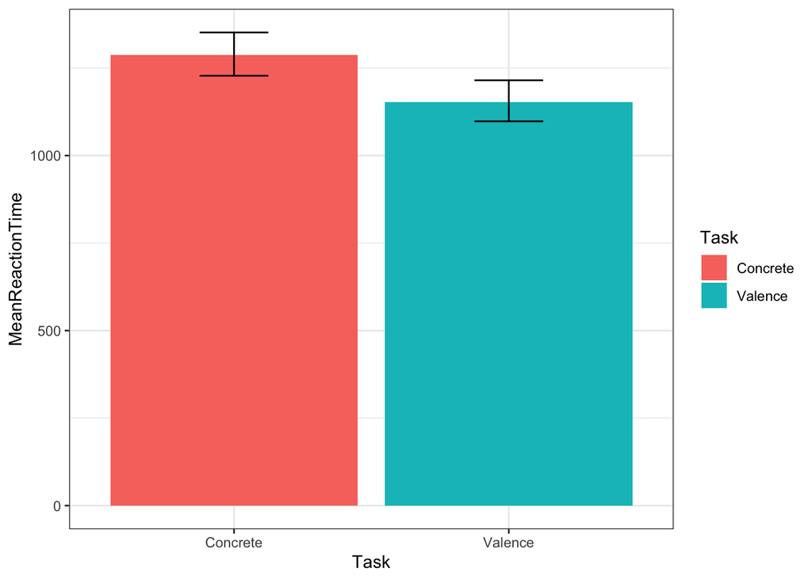

```r
agr <- d.train %>%
  group_by(Task) %>%
  summarize(MeanReactionTime = mean(ReactionTime),
          CILow = ci.low(ReactionTime),
          CIHigh = ci.high(ReactionTime)) %>%
  mutate(YMin = MeanReactionTime - CILow,
         YMax = MeanReactionTime + CIHigh)

dodge = position_dodge(.9)
ggplot(data=agr, aes(x=Task,y=MeanReactionTime,fill=Task)) +
  geom_bar(position=dodge,stat="identity") +
  geom_errorbar(aes(ymin=YMin,ymax=YMax),width=.25,position=position_dodge(0.9))
```

Plot as a function of trial order

```r
agr <- d.train %>%
  group_by(Task,TrialNumber) %>%
  summarize(MeanReactionTime = mean(ReactionTime),
          CILow = ci.low(ReactionTime),
          CIHigh = ci.high(ReactionTime)) %>%
  mutate(YMin = MeanReactionTime - CILow,
         YMax = MeanReactionTime + CIHigh)
```

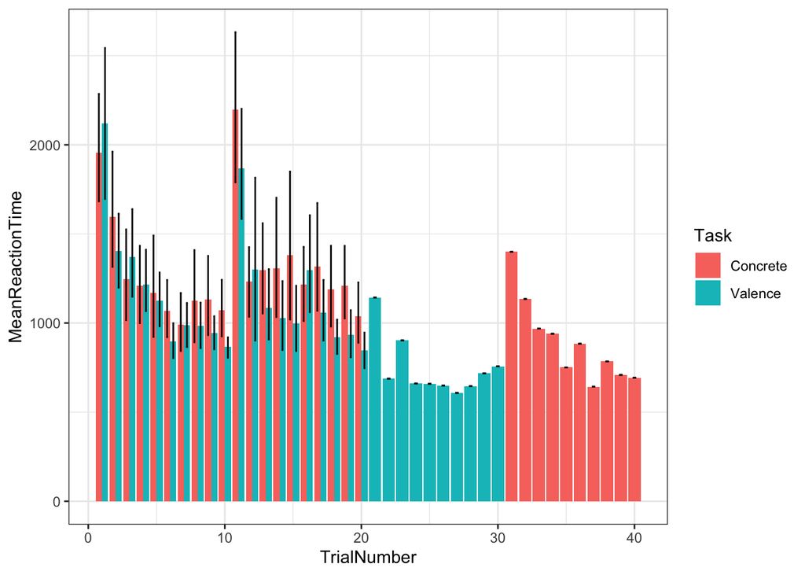

```r
dodge = position_dodge(.9)
ggplot(data=agr, aes(x=TrialNumber,y=MeanReactionTime,fill=Task)) +
  geom_bar(position=dodge,stat="identity") +
  geom_errorbar(aes(ymin=YMin,ymax=YMax),width=.25,position=position_dodge(0.9))
```

# Order differences?

This is doing something funky…so figure that out

```r
agr <- d %>%
  group_by(Task,TrialNumber) %>%
  summarize(MeanReactionTime = mean(ReactionTime),
          CILow = ci.low(ReactionTime),
          CIHigh = ci.high(ReactionTime)) %>%
  mutate(YMin = MeanReactionTime - CILow,
         YMax = MeanReactionTime + CIHigh)
```

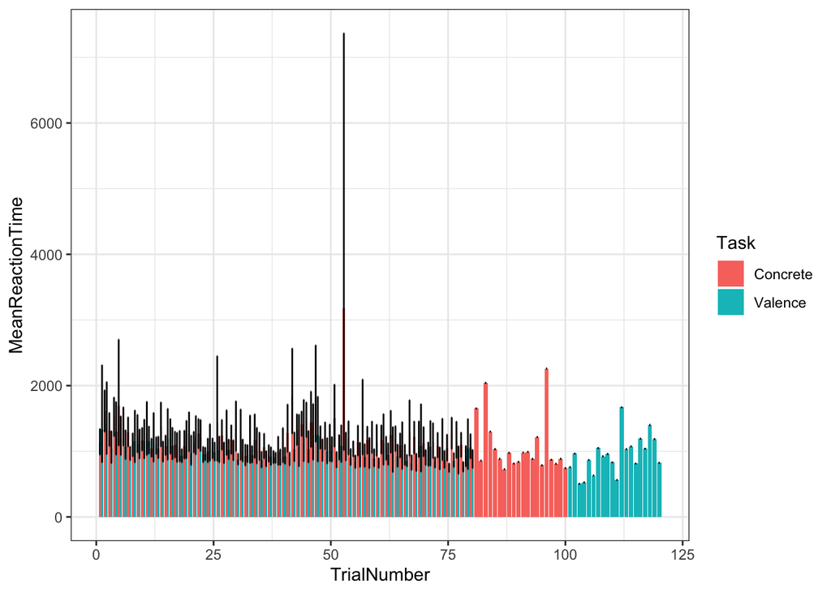

```r
dodge = position_dodge(.9)
ggplot(data=agr, aes(x=TrialNumber,y=MeanReactionTime,fill=Task)) +
  geom_bar(position=dodge,stat="identity") +
  geom_errorbar(aes(ymin=YMin,ymax=YMax),width=.25,position=position_dodge(0.9))
```

# Look at the test items where there was/wasn’t a switch in the lables

#Find participants in test items where F != abstract/negative and J != concrete/positive

```r
test.switch <- d %>%
  # Since training was always F = negative/abstract, switch is the opposite
  filter((Key_value_F %in% c("positive","concrete"))
           # (PennElementType == "Selector")
         )
switch.IDs <- test.switch$ID.true

# how many participants have the switch?
length(unique(test.switch$ID.true))
```

```
## [1] 40
```

```r
nrow(test.switch)
```

```
## [1] 1640
```

```r
# View(test.switch)
```

### How does accuracy and RT change in these cases?

Interestingly, Concrete accuracy is higher than for valance?

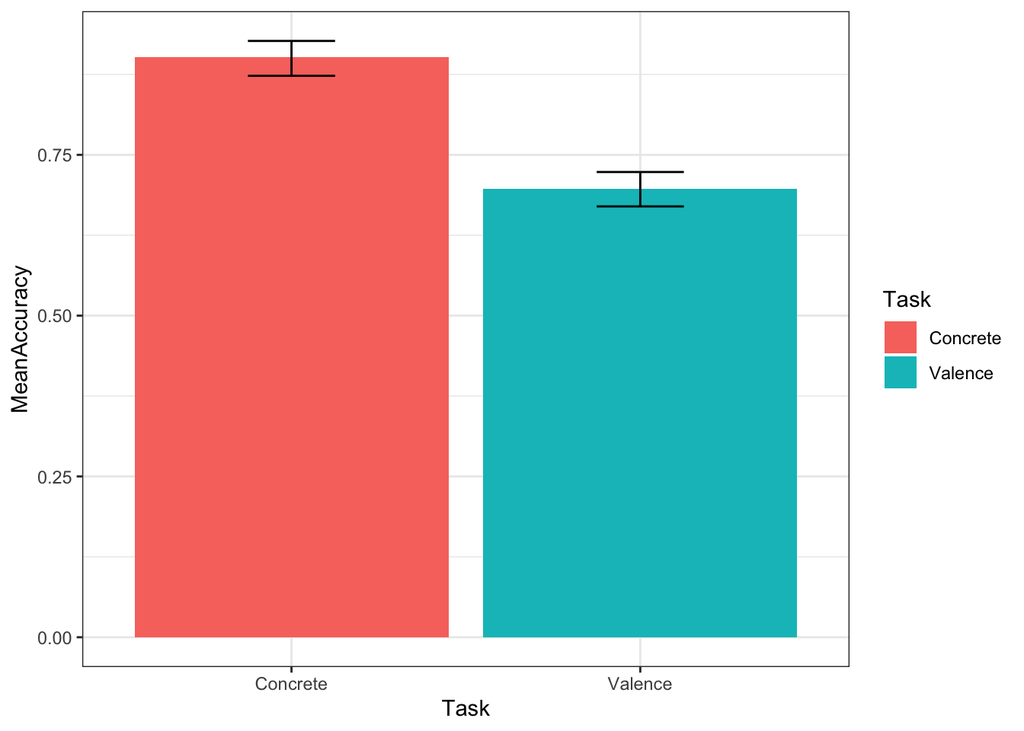

```r
agr <- test.switch %>%
  group_by(Task) %>%
  summarize(MeanAccuracy = mean(Accuracy),
          CILow = ci.low(Accuracy),
          CIHigh = ci.high(Accuracy)) %>%
  mutate(YMin = MeanAccuracy - CILow,
         YMax = MeanAccuracy + CIHigh)

dodge = position_dodge(.9)
ggplot(data=agr, aes(x=Task,y=MeanAccuracy,fill=Task)) +
  geom_bar(position=dodge,stat="identity") +
  geom_errorbar(aes(ymin=YMin,ymax=YMax),width=.25,position=position_dodge(0.9))
```

```r
agr <- test.switch %>%
  group_by(Task,Word) %>%
  summarize(MeanAccuracy = mean(Accuracy),
          CILow = ci.low(Accuracy),
          CIHigh = ci.high(Accuracy)) %>%
  mutate(YMin = MeanAccuracy - CILow,
         YMax = MeanAccuracy + CIHigh)
```

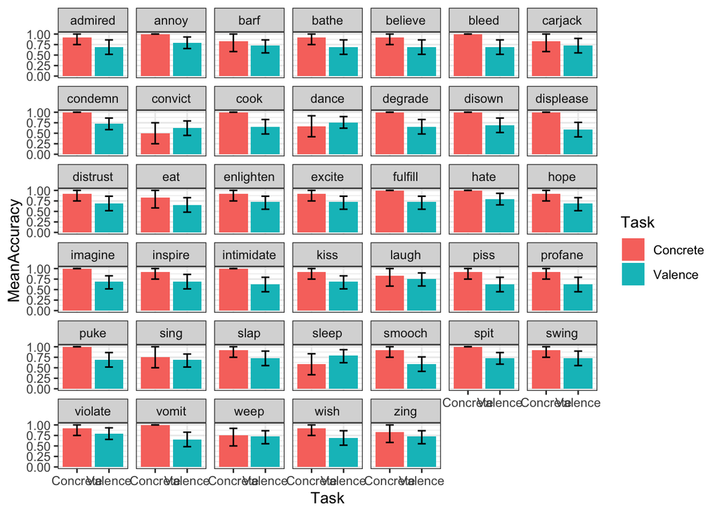

```r
dodge = position_dodge(.9)
ggplot(data=agr, aes(x=Task,y=MeanAccuracy,fill=Task)) +
  geom_bar(position=dodge,stat="identity") +
  facet_wrap(~Word) +
  geom_errorbar(aes(ymin=YMin,ymax=YMax),width=.25,position=position_dodge(0.9))
```

## Look at the ones where there is no switch

```r
test.no.switch <- d %>%
  filter(Key_value_F %in% c("negative","abstract")
         # (PennElementType == "Selector")
         )

nrow(test.no.switch)
```

```
## [1] 1600
```

```r
no.switch.IDs <- test.no.switch$ID.true


# how many participants have the switch?
length(unique(test.no.switch$ID.true))
```

```
## [1] 40
```

```r
# how many participants have the switch?
length(unique(d$ID.true))
```

```
## [1] 40
```

Wait, it’s surprising that in the no switch error cases that accuracy would be lower for concrete and higher for valance?

Things to look at: - is this due to a coding error? are the values for Accuracy getting reversed or something?

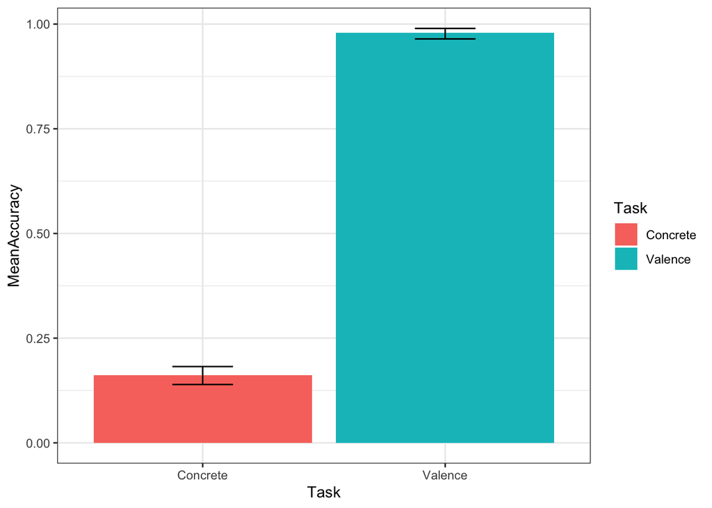

```r
agr <- test.no.switch %>%
  group_by(Task) %>%
  summarize(MeanAccuracy = mean(Accuracy),
          CILow = ci.low(Accuracy),
          CIHigh = ci.high(Accuracy)) %>%
  mutate(YMin = MeanAccuracy - CILow,
         YMax = MeanAccuracy + CIHigh)

dodge = position_dodge(.9)
ggplot(data=agr, aes(x=Task,y=MeanAccuracy,fill=Task)) +
  geom_bar(position=dodge,stat="identity") +
  geom_errorbar(aes(ymin=YMin,ymax=YMax),width=.25,position=position_dodge(0.9))
```

```r
agr <- test.no.switch %>%
  group_by(Task,Word) %>%
  summarize(MeanAccuracy = mean(Accuracy),
          CILow = ci.low(Accuracy),
          CIHigh = ci.high(Accuracy)) %>%
  mutate(YMin = MeanAccuracy - CILow,
         YMax = MeanAccuracy + CIHigh)
```

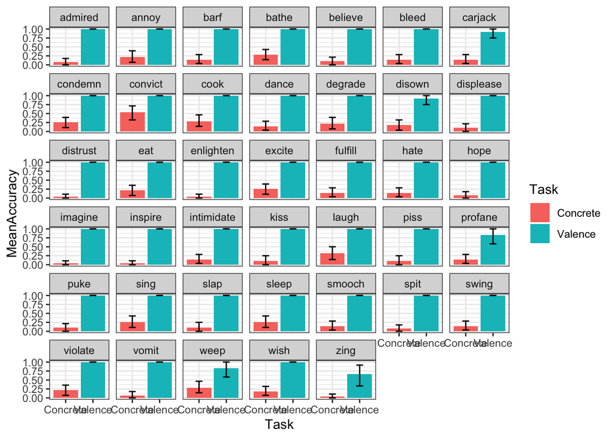

```r
dodge = position_dodge(.9)
ggplot(data=agr, aes(x=Task,y=MeanAccuracy,fill=Task)) +
  geom_bar(position=dodge,stat="identity") +
  facet_wrap(~Word) +
  geom_errorbar(aes(ymin=YMin,ymax=YMax),width=.25,position=position_dodge(0.9))
```

So it seems regardless of BlockOrder….but this must be a miscoding error

can it really be that NO participant is paying attention to the labels in the Concreteness task, but are in the Valence task??

To check out: - how are these participants doing in the training trials?

```r
agr <- test.no.switch %>%
  group_by(Task,BlockOrder,Word) %>%
  summarize(MeanAccuracy = mean(Accuracy),
          CILow = ci.low(Accuracy),
          CIHigh = ci.high(Accuracy)) %>%
  mutate(YMin = MeanAccuracy - CILow,
         YMax = MeanAccuracy + CIHigh)
```

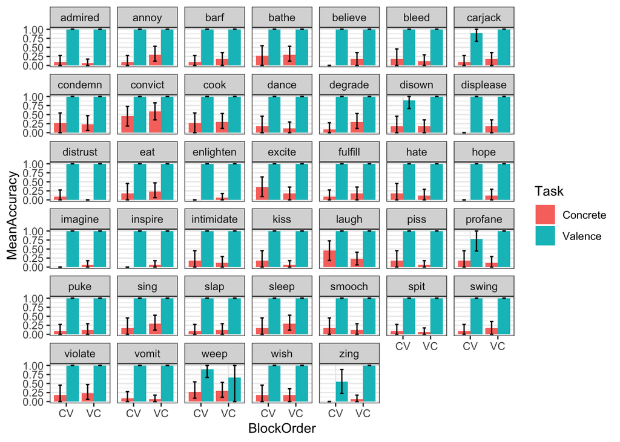

```r
dodge = position_dodge(.9)
ggplot(data=agr, aes(x=BlockOrder,y=MeanAccuracy,fill=Task)) +
  geom_bar(position=dodge,stat="identity") +
  facet_wrap(~Word) +
  geom_errorbar(aes(ymin=YMin,ymax=YMax),width=.25,position=position_dodge(0.9))
```

## In the No Switch trials

```r
test.no.switch.conc <- test.no.switch %>%
  filter(Task == "Concrete") %>%
  mutate(Response.n = ifelse(Response == "concrete", 1, 0) )

test.no.switch.conc$Response.n = as.numeric(test.no.switch.conc$Response.n)
```

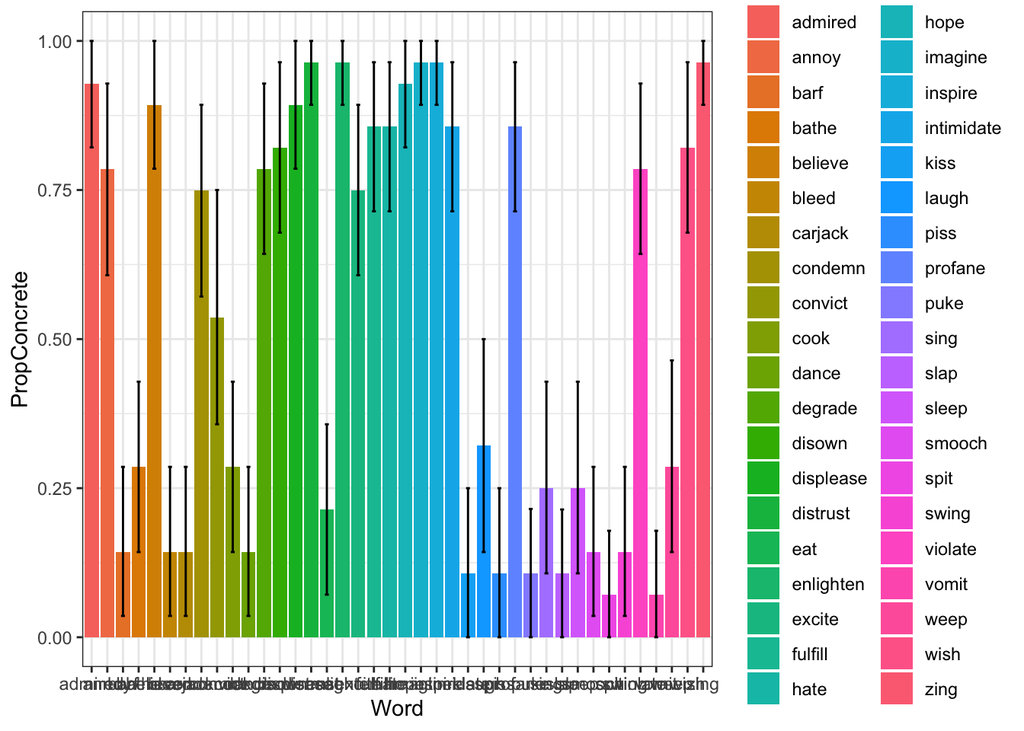

```r
agr <- test.no.switch.conc %>%
  group_by(Word) %>%
  summarize(PropConcrete = mean(Response.n),
          CILow = ci.low(Response.n),
          CIHigh = ci.high(Response.n)) %>%
  mutate(YMin = PropConcrete - CILow,
         YMax = PropConcrete + CIHigh)

dodge = position_dodge(.9)
ggplot(data=agr, aes(x=Word,y=PropConcrete,fill=Word)) +
  geom_bar(position=dodge,stat="identity") +
  geom_errorbar(aes(ymin=YMin,ymax=YMax),width=.25,position=position_dodge(0.9))
```

## In the Switch trials

```r
test.switch.conc <- test.switch %>%
  filter(Task == "Concrete") %>%
  mutate(Response.n = ifelse(Response == "concrete", 1, 0) )

test.switch.conc$Response.n = as.numeric(test.switch.conc$Response.n)
```

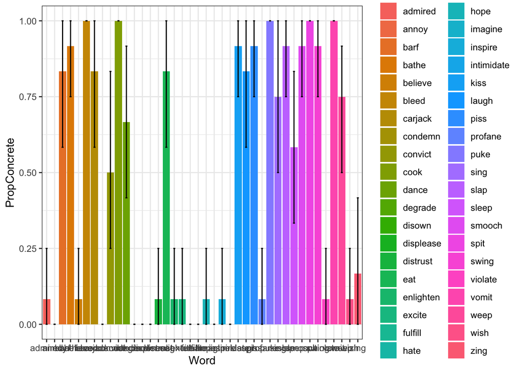

```r
agr <- test.switch.conc %>%
  group_by(Word) %>%
  summarize(PropConcrete = mean(Response.n),
          CILow = ci.low(Response.n),
          CIHigh = ci.high(Response.n)) %>%
  mutate(YMin = PropConcrete - CILow,
         YMax = PropConcrete + CIHigh)

dodge = position_dodge(.9)
ggplot(data=agr, aes(x=Word,y=PropConcrete,fill=Word)) +
  geom_bar(position=dodge,stat="identity") +
  geom_errorbar(aes(ymin=YMin,ymax=YMax),width=.25,position=position_dodge(0.9))
```

# Add a switch column

```r
# Add Task column
d$Switch <- ifelse(d$Key_value_F %in% c("concrete","positive"), "Switch","NoSwitch")
d$Response.n = as.numeric(d$Response)
```

What we can see from the following graph, is that the key labels are clearly inverted….but only for the concreteness task

```r
agr <- d %>%
  filter(Task == "Concrete") %>%
  mutate(Response.n = ifelse(Response == "concrete", 1, 0),
         Response.n = as.numeric(Response.n)) %>%
  group_by(Switch,Word) %>%
  summarize(PropConcrete = mean(Response.n),
          CILow = ci.low(Response.n),
          CIHigh = ci.high(Response.n)) %>%
  mutate(YMin = PropConcrete - CILow,
         YMax = PropConcrete + CIHigh)
```

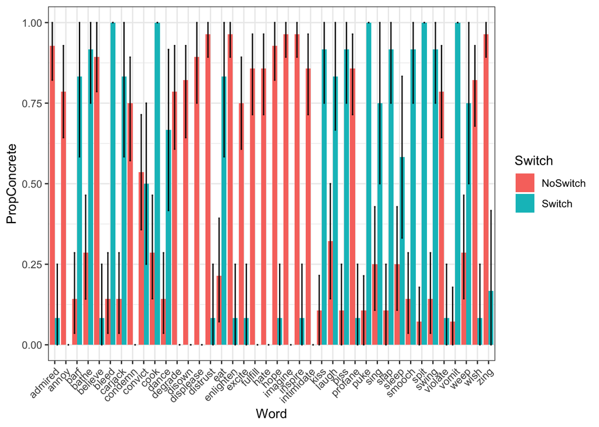

```r
dodge = position_dodge(.9)
ggplot(data=agr, aes(x=Word,y=PropConcrete,fill=Switch)) +
  geom_bar(position=dodge,stat="identity") +
  geom_errorbar(aes(ymin=YMin,ymax=YMax),width=.25,position=position_dodge(0.9)) +
  theme(axis.text.x = element_text(angle = 45, hjust = 1))
```

```r
agr <- d %>%
  filter(Task == "Valence") %>%
  mutate(Response.n = ifelse(Response == "concrete", 1, 0),
         Response.n = as.numeric(Response.n)) %>%
  group_by(Switch,Word) %>%
  summarize(PropPositive = mean(Response.n),
          CILow = ci.low(Response.n),
          CIHigh = ci.high(Response.n)) %>%
  mutate(YMin = PropPositive - CILow,
         YMax = PropPositive + CIHigh)
```

[figure not shown]

```r
dodge = position_dodge(.9)
ggplot(data=agr, aes(x=Word,y=PropPositive,fill=Switch)) +
  geom_bar(position=dodge,stat="identity") +
  geom_errorbar(aes(ymin=YMin,ymax=YMax),width=.25,position=position_dodge(0.9)) +
  theme(axis.text.x = element_text(angle = 45, hjust = 1))
```